# Лабораторна робота 1. Побудова простого лінійного бінарного класифікатора

[Недолужко Станіслав](https://github.com/TTelmewk1n) , 2024

## Завдання для самостійної роботи

1. Імпортувати дані для навчальної вибірки згідно з індивідуальним варіантом (імпорт організувати з файлу).
2. Побудувати бінарний класифікатор і вивести результати бінарної класифікації на графіку.
3. Дати відповіді на контрольні запитання.
4. Відправити результати роботи у файлі lab_1_StudentLastName.ipynb до віддаленого репозиторію на GіtHub.

# Виконання завдання:

```
Accuracy: 0.6
```

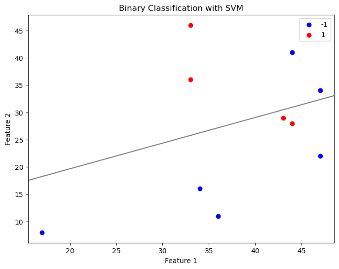

```python
import numpy as np
import matplotlib.pyplot as plt
from sklearn.svm import SVC
from sklearn.metrics import accuracy_score

# Вхідні дані
x_train_14 = np.array([[17, 8],
                      [33, 36],
                      [47, 22],
                      [36, 11],
                      [43, 29],
                      [33, 46],
                      [47, 34],
                      [34, 16],
                      [44, 28],
                      [44, 41]])
y_train_14 = np.array([-1, 1, -1, -1, 1, 1, -1, -1, 1, -1])  # -1 для синіх, 1 для червоних

# Побудова моделі
model = SVC(kernel='linear')
model.fit(x_train_14, y_train_14)

# Класифікація
y_pred = model.predict(x_train_14)
accuracy = accuracy_score(y_train_14, y_pred)
print("Accuracy:", accuracy)

# Відображення даних та розділної границі
plt.figure(figsize=(8, 6))

# Сині точки
plt.scatter(x_train_14[y_train_14 == -1][:, 0], x_train_14[y_train_14 == -1][:, 1], color='blue', label='-1')
# Червоні точки
plt.scatter(x_train_14[y_train_14 == 1][:, 0], x_train_14[y_train_14 == 1][:, 1], color='red', label='1')

# Створення сітки для візуалізації розділної границі
ax = plt.gca()
xlim = ax.get_xlim()
ylim = ax.get_ylim()

# Створення сітки для прогнозування розділної границі
xx, yy = np.meshgrid(np.linspace(xlim[0], xlim[1], 50),
                     np.linspace(ylim[0], ylim[1], 50))
Z = model.decision_function(np.c_[xx.ravel(), yy.ravel()])
Z = Z.reshape(xx.shape)

# Візуалізація розділної границі та меж класів
plt.contour(xx, yy, Z, colors='k', levels=[0], alpha=0.5, linestyles=['-'])
plt.title('Binary Classification with SVM')
plt.xlabel('Feature 1')
plt.ylabel('Feature 2')
plt.legend()

plt.show()
```

# Контрольні запитання

1. Основні принципи розпізнавання образів у контексті машинного навчання включають:
   - Використання навчальних даних для тренування моделі.
   - Використання алгоритмів класифікації та регресії для встановлення зв'язків між вхідними даними та вихідними мітками.
2. Навчальна вибірка - це набір даних, які використовуються для тренування моделі. Вона важлива для процесу розпізнавання образів, оскільки визначає, яким чином модель буде вчитися розпізнавати образи на основі вхідних даних та їх відповідних міток.
3. Постановка задачі бінарної класифікації полягає в тому, щоб розділити набір даних на два класи або категорії.
4. Рівняння гіперплощини - це лінійна розділяюча поверхня, яка використовується для розділення об'єктів у просторі на два класи. Це використовується для розв'язання задачі бінарної класифікації шляхом встановлення границі між класами.
5. Кроки для розв'язання простої задачі бінарної класифікації за допомогою машинного навчання включають:
   1. Збір та підготовка навчальних даних.
   2. Вибір моделі класифікації (наприклад, логістична регресія, метод опорних векторів тощо).
   3. Тренування моделі на навчальній вибірці.
   4. Оцінка та налаштування моделі за допомогою валідаційної вибірки.
   5. Тестування моделі на тестовій вибірці для оцінки її ефективності.